# Difference In Differences Introduction

Holden Nielson

## What is Difference In Differences

- Difference in Differences (DiD) is a causal inference method utilizing observational data
- DiD attempts to recreate an experiment by sorting data in nature into ‘treatment’ and ‘control’ groups
  - This is a called a ‘natural experiment’
- DiD is built on linear regression, and requires an addtional assumption to ensure the it explains a causal outcome

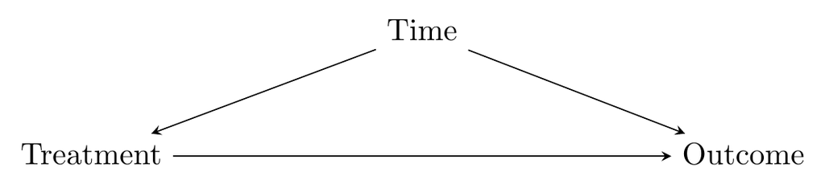

DAG w/ Time Backdoor

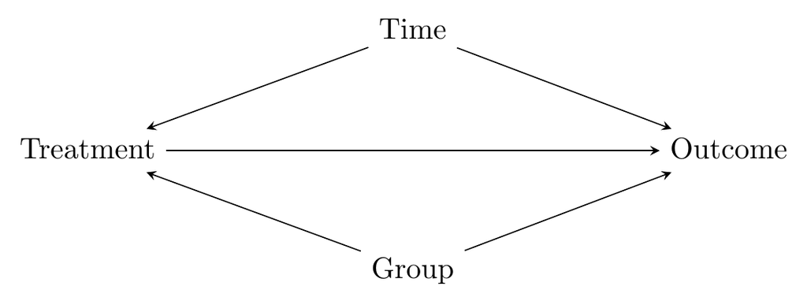

DAG w/ Time & Group Backdoor

## DiD Closes Both Backdoors at Once

- We will close the Group backdoor by controlling for group differences (again group is ‘treatment’ or ‘control’)
- We will close the Time backdoor by comparing variation within each group over time
- Essentially we are looking for how much MORE the treatment group was impacted over time versus the control group (the difference in differences)

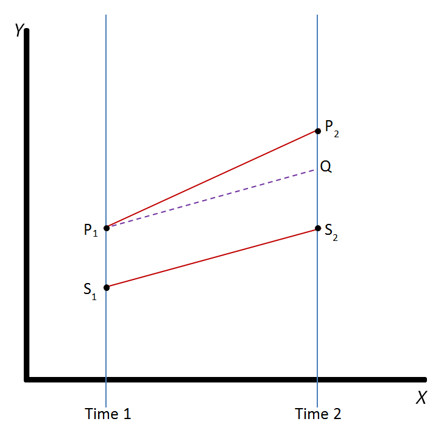

Simple Illustration of DiD

## EX: John Snow’s 1855 Proof of Cholera’s Source

- John Snow in 1855 found that Cholera was spread via contaminated water and not airborn infection
- London had a major water company Lambeth who was legally required to move their water supply from downstream to upstream between the period from 1849 and 1854
  - Seems like a good instance to test whether drinking contaminated water contributed to Cholera death
- However, if Snow only catalogued the difference in Cholera death rate from 1849 and 1854, he would have no evidence the Lambeth change had caused it
- So Snow collected data on Cholera death rate for two groups: Lambeth customers (‘treatment’) and other sources (‘control’)

| Source of Water | Death Rate 1849 | Death Rate 1854 |
| --- | --- | --- |
| Non-Lambeth | 134.9 | 146.6 |
| Lambeth | 130.1 | 84.9 |
| Death rate is deaths per 10,000 Londoners |  |  |

|  | New Jersey | Pennsylvania | Diff |
| --- | --- | --- | --- |
| February | 20.44 | 23.33 | −2.89 |
| November | 21.03 | 21.17 | -0.14 |
| Change | 0.59 | -2.16 | 2.75 |

## Using DiD

- The hardest part of implmenting a DiD model is finding a suitable set of ‘treatment’ and ‘control’ groups
  - The two groups must have a convincing reason to believe they would act similarly in the case of a counterfactual with no treatment
- Your dataset must include information on these groups and must include time period data for at least two points (pre-treatment and post-treatment)

## Parallel Trends Assumption

- In addition to the traditional linear regression assumptions, to utilize DiD, your data must fit the ‘Parallel Trends’ assumption
- Parallel Trends Assumption: In the absense of a treatment, the trend/difference between ‘treatment’ and ‘control’ would have remained the same
- This assumption is unobservable – you cannot see the counterfactual where the treatment did not occur – but it can be justified
  - Beyond reasoning which justifies that there are no unobserved cofounders, you can also use prior trends and placebo tests
    - Both of these methods involve showing a parallel trend prior to the ‘treatment period’

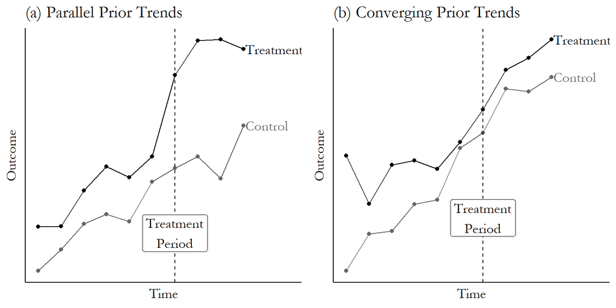

Left: Good Prior Trends, Right: Bad Prior Trends

## Performing DiD: Two Time Periods

$$Y = \alpha_g + \alpha_t + \beta_1 Treated + \epsilon$$

- $\alpha_g$ is fixed effects/intercepts for all of your groups
- $\alpha_t$ is fixed effcts/intercepts for your time periods
- $Treated$ is a dummy variable which is true when an observation occurs both:
  - Post Treatment
  - Within the Treatment group

$$Y = \beta_0 + \beta_1 TreatedGroup + \beta_2 AfterTreatment + \\
\beta_3 (TreatedGroup \times AfterTreatment) + \epsilon$$

## Performing DiD: Interaction Term with Time

$$Y = \beta_0 + \beta_1 Time + \beta_2 Treatment +\\ \beta_3 Treatment \times Time + \epsilon$$

- This regression understands the treatment more as a break in the literal linear trend
- Utilizing many time periods might stress the amount of data you have and introduce noisier results

## Alternatively:

$$Y = \alpha_g + \alpha_t + \beta_{-T_1} Treated + \beta_{-(T_1 - 1)} Treated + \ldots\\ + B_{-1} Treated + \beta_1 Treated + \ldots\\ \beta_{T_2} Treated + \epsilon$$

- Where $T_1$ is the number of time periods before treatment, $T_2$ the number of time periods after treatment and $\beta_{n}$ is the DiD calculation at time period $n$
- The betas less than 0 should be close to zero and serve as a form of placebo testing of parallel trends

## Testing Parallel Trends:

- Utilizing only pretreatment data, we can see if the ‘treatment’ and ‘control’ group display parallel trends

$$Y = \alpha_g + \beta_1 Time + \beta_2 (Time \times Group) + \epsilon$$

- If the coefficient for $\beta_2$ is already large without including the post-treatment time periods, then you likely do not have parallel trends

## Performing DiD: Utilizing Covariates?

- Perhaps our DAG or our analysis of prior trends will indicate that the parallel trends assumption might not hold
- This might be a sign to utilize a different method/dataset, but Covariates could be utilized instead to demonstrate that, controlling for an additional factor, parallel trends hold
- There inclusion can get thorny though, and might undermine our assumptions or our treatment results